# A Classification problem solution attempt with Decision Tree Classifiers, Random Forest Classifiers, Artificial Neural Networks, Gradient Boosting Classifier, K-Neighbors Classifier & Logistic Regression

🕸🕸🕸🕸🕸🕸🕸🕸🕸🕸🕸🕸🌲🌳🌲🌲🌳🌲🌲🌳🌲🌲🌳🌲🌲🌳🌲🌲🌲🌳🌲🌲🌳🌲🌲🌳🌲🌲🌳🌲🌲🌳🌲🌲🌳🕸🕸🕸🕸🕸🕸🕸🕸🕸🕸🕸🕸

Sources: (a) Original owner of the database:

R. K. Bock Major Atmospheric Gamma Imaging Cherenkov Telescope project (MAGIC) http://wwwmagic.mppmu.mpg.de rkb@mail.cern.ch

(b) Donor:

P. Savicky Institute of Computer Science, AS of CR Czech Republic savicky@cs.cas.cz

# Importing libraries

```python
#This cell was used to install mpld3. It allows to manipulate plots: zoom and moving
#!pip install mpld3
```

```python
#%matplotlib inline
#import mpld3
#mpld3.enable_notebook()
```

```python
#plots and style
import matplotlib.pyplot as plt
import seaborn as sns; sns.set_theme()
import matplotlib.style as sty
#sty.use('ggplot')
sty.use('seaborn-whitegrid')
from matplotlib.pyplot import figure
```

```python
#To avoid the warnings
import warnings
warnings.simplefilter(action='ignore', category=FutureWarning)
```

```python
import numpy as np
import pandas as pd
import sys, os

#to not print
class HiddenPrints:
    def __enter__(self):
        self._original_stdout = sys.stdout
        sys.stdout = open(os.devnull, 'w')

    def __exit__(self, exc_type, exc_val, exc_tb):
        sys.stdout.close()
        sys.stdout = self._original_stdout

#to print tables in LaTex
#!pip install tabulate
from tabulate import tabulate
```

```python
#ROC curve and AUC
from sklearn.metrics import roc_curve, auc
```

```python
#importing all possible distributions
from scipy.stats import genextreme
from scipy.stats import gamma
from scipy.stats import t
from scipy.stats import dweibull
from scipy.stats import beta
from scipy.stats import norm
from scipy.stats import expon
from scipy.stats import pareto
from scipy.stats import genextreme
from scipy.stats import uniform
from scipy.stats import logistic
from scipy.stats import kstest
from scipy.stats import ks_2samp
from scipy.stats import lognorm
#this distribution is for annother purpose
from scipy.stats import loguniform
```

```python
# Importing train_test_split to split our data
from sklearn.model_selection import train_test_split
```

```python
# From the distfit library import the class distfit
from distfit import distfit
```

```python
# Importing Decision Tree Model
from sklearn.tree import DecisionTreeClassifier
# Importing Random Forest Model
from sklearn.ensemble import RandomForestClassifier
# Importing GBC
from sklearn.ensemble import GradientBoostingClassifier
#Importing KNeighborsClassifier
from sklearn.neighbors import KNeighborsClassifier
#Importing Logistic Regression
from sklearn.linear_model import LogisticRegression

# Importing mean_absolute_error to find Mean absolute error of each model
from sklearn.metrics import mean_absolute_error

from sklearn.metrics import confusion_matrix
from sklearn.metrics import accuracy_score, confusion_matrix, precision_score, recall_score, f1_score
```

```python
#To normalize data
from sklearn.preprocessing import StandardScaler
```

```python
#import keras ANN
from keras.models import Sequential
from keras.layers import Dense, Dropout
```

```python
#cross vaidation
from sklearn.model_selection import cross_val_score
#Hyperparameter tunning
from sklearn.model_selection import GridSearchCV,cross_validate, RandomizedSearchCV
from tensorflow.keras.wrappers.scikit_learn import KerasClassifier
```

```python
#optimizer for the cuts
from scipy.optimize import minimize
```

```python
font = {
        'size'   : 19}
#to set a biggers size of text in plots
from matplotlib import rc
rc('font', **font)
```

# Displaying Data

```python
df = pd.read_csv('telescope_data.csv')#importing data
del df['Unnamed: 0']#this column was empty
df.head()
```

|  | fLength | fWidth | fSize | fConc | fConc1 | fAsym | fM3Long | fM3Trans | fAlpha | fDist | class |
| --- | --- | --- | --- | --- | --- | --- | --- | --- | --- | --- | --- |
| 0 | 28.7967 | 16.0021 | 2.6449 | 0.3918 | 0.1982 | 27.7004 | 22.0110 | -8.2027 | 40.0920 | 81.8828 | g |
| 1 | 31.6036 | 11.7235 | 2.5185 | 0.5303 | 0.3773 | 26.2722 | 23.8238 | -9.9574 | 6.3609 | 205.2610 | g |
| 2 | 162.0520 | 136.0310 | 4.0612 | 0.0374 | 0.0187 | 116.7410 | -64.8580 | -45.2160 | 76.9600 | 256.7880 | g |
| 3 | 23.8172 | 9.5728 | 2.3385 | 0.6147 | 0.3922 | 27.2107 | -6.4633 | -7.1513 | 10.4490 | 116.7370 | g |
| 4 | 75.1362 | 30.9205 | 3.1611 | 0.3168 | 0.1832 | -5.5277 | 28.5525 | 21.8393 | 4.6480 | 356.4620 | g |

Summary the raw data

```python
df.info()
```

```
<class 'pandas.core.frame.DataFrame'>
RangeIndex: 19020 entries, 0 to 19019
Data columns (total 11 columns):
 #   Column    Non-Null Count  Dtype
---  ------    --------------  -----
 0   fLength   19020 non-null  float64
 1   fWidth    19020 non-null  float64
 2   fSize     19020 non-null  float64
 3   fConc     19020 non-null  float64
 4   fConc1    19020 non-null  float64
 5   fAsym     19020 non-null  float64
 6   fM3Long   19020 non-null  float64
 7   fM3Trans  19020 non-null  float64
 8   fAlpha    19020 non-null  float64
 9   fDist     19020 non-null  float64
 10  class     19020 non-null  object
dtypes: float64(10), object(1)
memory usage: 1.6+ MB
```

There are not missing values so we don't need to use pipelines to structure the data

```python
df.describe()
```

|  | fLength | fWidth | fSize | fConc | fConc1 | fAsym | fM3Long | fM3Trans | fAlpha | fDist |
| --- | --- | --- | --- | --- | --- | --- | --- | --- | --- | --- |
| count | 19020.000000 | 19020.000000 | 19020.000000 | 19020.000000 | 19020.000000 | 19020.000000 | 19020.000000 | 19020.000000 | 19020.000000 | 19020.000000 |
| mean | 53.250154 | 22.180966 | 2.825017 | 0.380327 | 0.214657 | -4.331745 | 10.545545 | 0.249726 | 27.645707 | 193.818026 |
| std | 42.364855 | 18.346056 | 0.472599 | 0.182813 | 0.110511 | 59.206062 | 51.000118 | 20.827439 | 26.103621 | 74.731787 |
| min | 4.283500 | 0.000000 | 1.941300 | 0.013100 | 0.000300 | -457.916100 | -331.780000 | -205.894700 | 0.000000 | 1.282600 |
| 25% | 24.336000 | 11.863800 | 2.477100 | 0.235800 | 0.128475 | -20.586550 | -12.842775 | -10.849375 | 5.547925 | 142.492250 |
| 50% | 37.147700 | 17.139900 | 2.739600 | 0.354150 | 0.196500 | 4.013050 | 15.314100 | 0.666200 | 17.679500 | 191.851450 |
| 75% | 70.122175 | 24.739475 | 3.101600 | 0.503700 | 0.285225 | 24.063700 | 35.837800 | 10.946425 | 45.883550 | 240.563825 |
| max | 334.177000 | 256.382000 | 5.323300 | 0.893000 | 0.675200 | 575.240700 | 238.321000 | 179.851000 | 90.000000 | 495.561000 |

```python
df.shape
```

```
(19020, 11)
```

The data has 11 variables with 19020 events:

1. fLength: continuous - major axis of ellipse [mm]
2. fWidth: continuous - minor axis of ellipse [mm]
3. fSize: continuous - 10-log of sum of content of all pixels [in #phot]
4. fConc: continuous - ratio of sum of two highest pixels over fSize [ratio]
5. fConc1: continuous - ratio of highest pixel over fSize [ratio]
6. fAsym: continuous - distance from highest pixel to center, projected onto major axis [mm]
7. fM3Long: continuous - 3rd root of third moment along major axis [mm]
8. fM3Trans: continuous - 3rd root of third moment along minor axis [mm]
9. fAlpha: continuous - angle of major axis with vector to origin [deg]
10. fDist: continuous - distance from origin to center of ellipse [mm]
11. class: g,h - gamma (signal), hadron (background)

## Check distribution and correlations

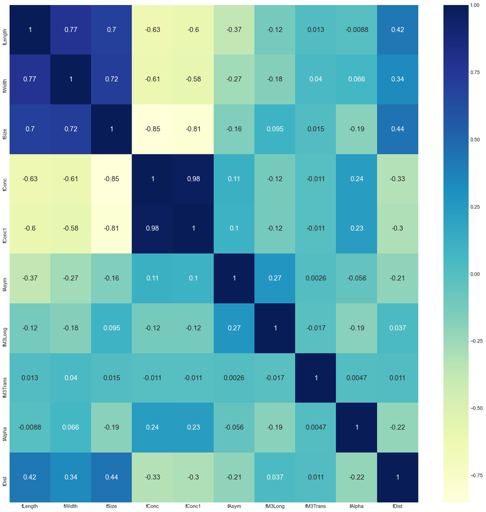

```python
plt.figure(figsize=(20, 20))
#Compute pairwise correlation of columns, excluding NA/null values. It displays pearson standard correlation coefficient
sns.heatmap(df.corr(), annot=True, cmap="YlGnBu", annot_kws={"size":15})
```

It is notorious that there is a high correlation between *fConc* and *fConc1*, but that is rather obvious from their definitions:

1. fConc: continuous - ratio of sum of the two highest pixels over fSize [ratio]
2. fConc1: continuous - ratio of the highest pixel over fSize [ratio]

Before looking for the distributions it is needed to separate the data in training and test categories:

```python
# Create target object and call it y
y = df['class'].replace('g',1).replace('h',0)

# Create X
features = list(df)[:-1]#without the last column
X = df[features]
```

```python
# Split into validation and training data
train_X, val_X, train_y, val_y = train_test_split(X, y, test_size = 0.25, random_state = 0)
```

Pearson pairwise correlation of the train data categories with the binary target category : Signal

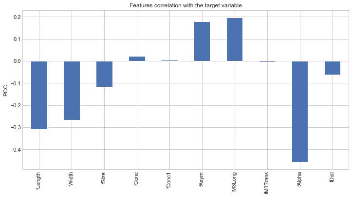

```python
train_X.corrwith(train_y).plot(kind='bar', figsize=(12, 6), title='Features correlation with the target variable')
plt.ylabel("PCC")
plt.show()
```

The most strong correlation is a negative correlation between *fAlpha ("continuous - angle of major axis with vector to origin [deg]")* and the target binary variable *class*.

## Testing distributions on the parameters of the train data

A kernel density estimation (KDE) is a non-parametric way to estimate the probability density function (PDF) of a random variable. These are KDE plots on top of the distribution histograms:

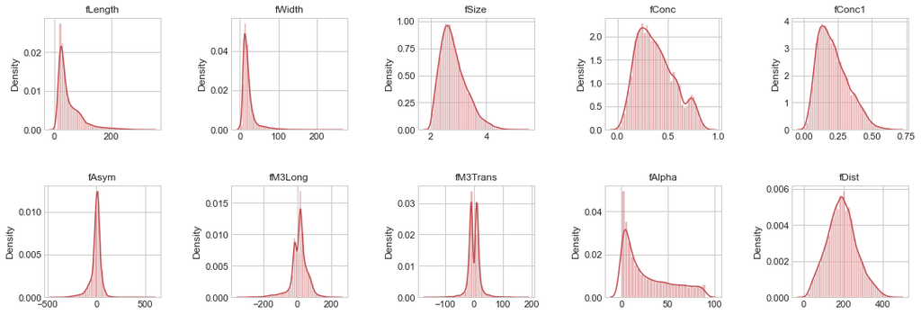

```python
fig, ax = plt.subplots(2,5, figsize=(16, 6))
ax = ax.flatten()
for i in range(10):
    sns.distplot(train_X.iloc[:,i].values,ax=ax[i],color='r')#it plots both the histogram and the KDE
    ax[i].set_title(train_X.columns[i])#title of the histogram
fig.tight_layout(pad=2.0)
```

Disfit is a package that proves some possible distributions (89) and looks for the best theoretical distribution using the Residual Sum of Squares (RSS) estimates. It starts with interpolation to smooth a histogram of the distribution. Then it uses the RSS to look for the best distributions. This is a good way to obtain the best distribution and the RSS of the most popular models.

```
[distfit] >fit..
[distfit] >transform..
[distfit] >[norm      ] [RSS: 0.0008238] [loc=53.457 scale=43.056]
[distfit] >[expon     ] [RSS: 0.0007048] [loc=4.284 scale=49.174]
[distfit] >[pareto    ] [RSS: 0.0029099] [loc=-0.008 scale=4.291]
[distfit] >[dweibull  ] [RSS: 0.0004258] [loc=32.517 scale=26.580]
[distfit] >[t         ] [RSS: 0.0004800] [loc=37.070 scale=20.196]
[distfit] >[genextreme] [RSS: 0.0000708] [loc=30.620 scale=17.712]
[distfit] >[gamma     ] [RSS: 0.0003334] [loc=4.277 scale=27.514]
[distfit] >[lognorm   ] [RSS: 0.0024580] [loc=4.283 scale=3.028]
[distfit] >[beta      ] [RSS: 0.0003345] [loc=4.277 scale=6629220575.237]
[distfit] >[uniform   ] [RSS: 0.0015846] [loc=4.284 scale=329.894]
[distfit] >Compute confidence interval [parametric]
[distfit] >plot..
```

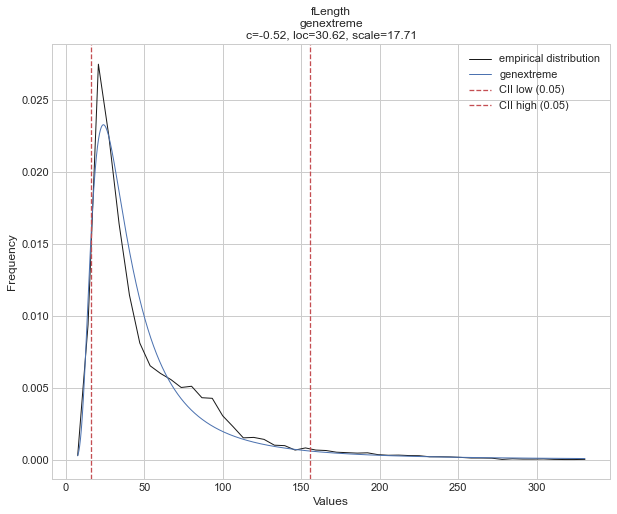

```
[distfit] >fit..
[distfit] >transform..
[distfit] >[norm      ] [RSS: 0.0022657] [loc=22.241 scale=18.645]
[distfit] >[expon     ] [RSS: 0.0029952] [loc=0.000 scale=22.241]
[distfit] >[pareto    ] [RSS: 0.0073812] [loc=-3.115 scale=3.115]
[distfit] >[dweibull  ] [RSS: 0.0005543] [loc=16.308 scale=9.375]
[distfit] >[t         ] [RSS: 0.0002920] [loc=16.485 scale=6.342]
[distfit] >[genextreme] [RSS: 0.0001671] [loc=14.619 scale=8.279]
[distfit] >[gamma     ] [RSS: 0.0007863] [loc=-0.634 scale=9.070]
[distfit] >[lognorm   ] [RSS: 0.0003792] [loc=-2.667 scale=20.991]
[distfit] >[beta      ] [RSS: 0.0008131] [loc=-0.596 scale=166546178985.119]
[distfit] >[uniform   ] [RSS: 0.0056181] [loc=0.000 scale=256.382]
[distfit] >Compute confidence interval [parametric]
[distfit] >plot..
```

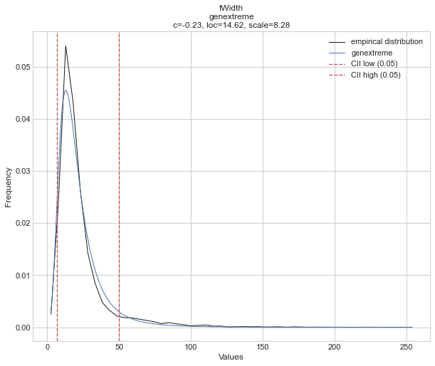

```
[distfit] >fit..
[distfit] >transform..
[distfit] >[norm      ] [RSS: 0.6279483] [loc=2.824 scale=0.472]
[distfit] >[expon     ] [RSS: 4.0566499] [loc=1.947 scale=0.877]
[distfit] >[pareto    ] [RSS: 5.7587757] [loc=-0.042 scale=1.989]
[distfit] >[dweibull  ] [RSS: 0.8185592] [loc=2.792 scale=0.396]
[distfit] >[t         ] [RSS: 0.5201262] [loc=2.794 scale=0.426]
[distfit] >[genextreme] [RSS: 0.0495485] [loc=2.606 scale=0.370]
[distfit] >[gamma     ] [RSS: 0.0282840] [loc=1.921 scale=0.255]
[distfit] >[lognorm   ] [RSS: 0.0360586] [loc=1.593 scale=1.146]
[distfit] >[beta      ] [RSS: 0.0318266] [loc=1.942 scale=7.808]
[distfit] >[uniform   ] [RSS: 5.3198046] [loc=1.947 scale=3.376]
[distfit] >Compute confidence interval [parametric]
[distfit] >plot..
```

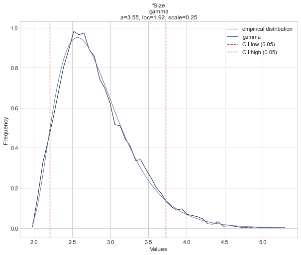

```
[distfit] >fit..
[distfit] >transform..
[distfit] >[norm      ] [RSS: 6.1926246] [loc=0.381 scale=0.183]
[distfit] >[expon     ] [RSS: 39.1630033] [loc=0.013 scale=0.368]
[distfit] >[pareto    ] [RSS: 36.2632547] [loc=-29317.168 scale=29317.181]
[distfit] >[dweibull  ] [RSS: 8.0966123] [loc=0.374 scale=0.164]
[distfit] >[t         ] [RSS: 6.1937253] [loc=0.381 scale=0.183]
[distfit] >[genextreme] [RSS: 2.4931807] [loc=0.301 scale=0.157]
[distfit] >[gamma     ] [RSS: 1.6033370] [loc=-0.042 scale=0.084]
[distfit] >[lognorm   ] [RSS: 2.0545347] [loc=-0.238 scale=0.593]
[distfit] >[beta      ] [RSS: 1.8778444] [loc=0.011 scale=1.046]
[distfit] >[uniform   ] [RSS: 25.3005185] [loc=0.013 scale=0.880]
[distfit] >Compute confidence interval [parametric]
[distfit] >plot..
```

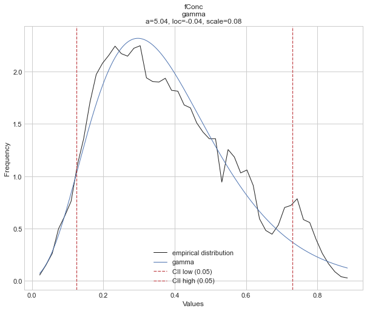

```
[distfit] >fit..
[distfit] >transform..
[distfit] >[norm      ] [RSS: 14.5504566] [loc=0.215 scale=0.111]
[distfit] >[expon     ] [RSS: 86.4852924] [loc=0.000 scale=0.215]
[distfit] >[pareto    ] [RSS: 86.9637038] [loc=-1397449.525 scale=1397449.526]
[distfit] >[dweibull  ] [RSS: 20.4854740] [loc=0.209 scale=0.097]
[distfit] >[t         ] [RSS: 14.5022300] [loc=0.215 scale=0.111]
[distfit] >[genextreme] [RSS: 3.3369324] [loc=0.164 scale=0.090]
[distfit] >[gamma     ] [RSS: 1.6243850] [loc=-0.014 scale=0.056]
[distfit] >[lognorm   ] [RSS: 2.4153420] [loc=-0.095 scale=0.291]
[distfit] >[beta      ] [RSS: 1.7704505] [loc=-0.002 scale=1.091]
[distfit] >[uniform   ] [RSS: 90.3234778] [loc=0.000 scale=0.675]
[distfit] >Compute confidence interval [parametric]
[distfit] >plot..
```

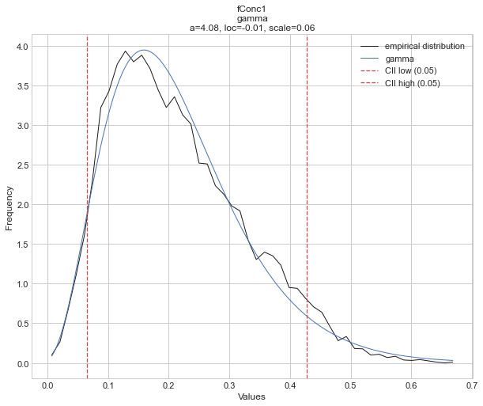

```
[distfit] >fit..
[distfit] >transform..
[distfit] >[norm      ] [RSS: 0.0000739] [loc=-4.561 scale=59.668]
[distfit] >[expon     ] [RSS: 0.0003350] [loc=-449.953 scale=445.392]
[distfit] >[pareto    ] [RSS: 0.0003222] [loc=-3560720.763 scale=3560270.793]
[distfit] >[dweibull  ] [RSS: 0.0000072] [loc=4.067 scale=35.483]
[distfit] >[t         ] [RSS: 0.0000026] [loc=5.061 scale=27.058]
[distfit] >[genextreme] [RSS: 0.0003736] [loc=574.857 scale=3.477]
[distfit] >[gamma     ] [RSS: 0.0000882] [loc=-744.222 scale=5.404]
[distfit] >[lognorm   ] [RSS: 0.0004332] [loc=-449.953 scale=8.025]
[distfit] >[beta      ] [RSS: 0.0000721] [loc=-13641.414 scale=15514.513]
[distfit] >[uniform   ] [RSS: 0.0003146] [loc=-449.953 scale=1025.193]
[distfit] >Compute confidence interval [parametric]
[distfit] >plot..
```

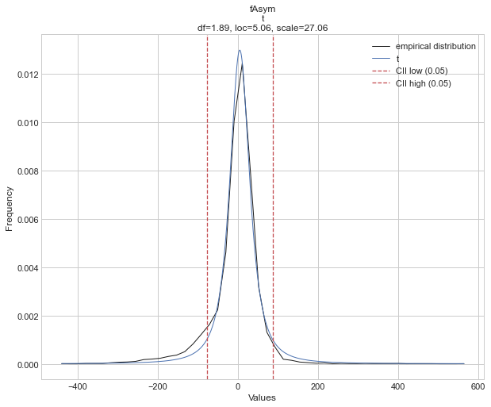

```
[distfit] >fit..
[distfit] >transform..
[distfit] >[norm      ] [RSS: 0.0001345] [loc=10.301 scale=51.722]
[distfit] >[expon     ] [RSS: 0.0006436] [loc=-331.780 scale=342.081]
[distfit] >[pareto    ] [RSS: 0.0006260] [loc=-46449814487.046 scale=46449814155.266]
[distfit] >[dweibull  ] [RSS: 0.0000509] [loc=16.190 scale=32.972]
[distfit] >[t         ] [RSS: 0.0000609] [loc=14.167 scale=29.975]
[distfit] >[genextreme] [RSS: 0.0007580] [loc=237.907 scale=3.192]
[distfit] >[gamma     ] [RSS: 0.0001791] [loc=-335.645 scale=10.096]
[distfit] >[lognorm   ] [RSS: 0.0001336] [loc=-16211.650 scale=16222.055]
[distfit] >[beta      ] [RSS: 0.0001290] [loc=-656596.974 scale=656882.520]
[distfit] >[uniform   ] [RSS: 0.0005571] [loc=-331.780 scale=570.101]
[distfit] >Compute confidence interval [parametric]
[distfit] >plot..
```

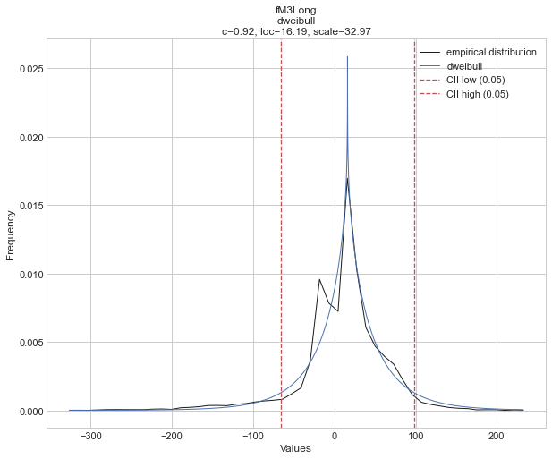

```
[distfit] >fit..
[distfit] >transform..
[distfit] >[norm      ] [RSS: 0.0006329] [loc=0.231 scale=20.982]
[distfit] >[expon     ] [RSS: 0.0027997] [loc=-164.140 scale=164.371]
[distfit] >[pareto    ] [RSS: 0.0027414] [loc=-5847212965.351 scale=5847212801.211]
[distfit] >[dweibull  ] [RSS: 0.0004889] [loc=0.183 scale=16.000]
[distfit] >[t         ] [RSS: 0.0005865] [loc=0.093 scale=13.670]
[distfit] >[genextreme] [RSS: 0.0009438] [loc=-8.486 scale=25.394]
[distfit] >[gamma     ] [RSS: 0.0006380] [loc=-502.329 scale=0.887]
[distfit] >[lognorm   ] [RSS: 0.0036828] [loc=-164.140 scale=1.965]
[distfit] >[beta      ] [RSS: 0.0006325] [loc=-1622.590 scale=8338.412]
[distfit] >[uniform   ] [RSS: 0.0025978] [loc=-164.140 scale=343.991]
[distfit] >Compute confidence interval [parametric]
[distfit] >plot..
```

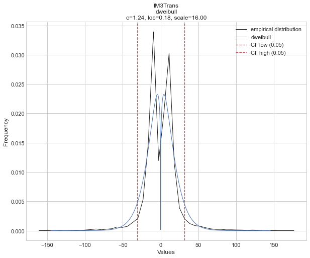

```
[distfit] >fit..
[distfit] >transform..
[distfit] >[norm      ] [RSS: 0.0054292] [loc=27.709 scale=26.155]
[distfit] >[expon     ] [RSS: 0.0010020] [loc=0.000 scale=27.709]
[distfit] >[pareto    ] [RSS: 0.0011171] [loc=-350630.409 scale=350630.409]
[distfit] >[dweibull  ] [RSS: 0.0051886] [loc=32.269 scale=26.029]
[distfit] >[t         ] [RSS: 0.0054292] [loc=27.708 scale=26.154]
[distfit] >[genextreme] [RSS: 0.0015523] [loc=10.200 scale=12.000]
[distfit] >[gamma     ] [RSS: 0.0006142] [loc=-0.000 scale=28.173]
[distfit] >[lognorm   ] [RSS: 0.0126030] [loc=-0.000 scale=1.682]
[distfit] >[beta      ] [RSS: 0.0006344] [loc=-0.000 scale=91.020]
[distfit] >[uniform   ] [RSS: 0.0053099] [loc=0.000 scale=90.000]
[distfit] >Compute confidence interval [parametric]
[distfit] >plot..
```

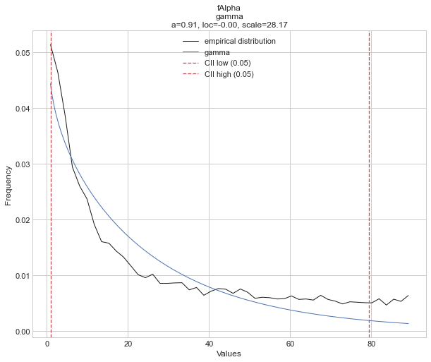

```
[distfit] >fit..
[distfit] >transform..
[distfit] >[norm      ] [RSS: 0.0000030] [loc=193.614 scale=74.718]
[distfit] >[expon     ] [RSS: 0.0002424] [loc=1.283 scale=192.332]
[distfit] >[pareto    ] [RSS: 0.0010388] [loc=0.001 scale=1.282]
[distfit] >[dweibull  ] [RSS: 0.0000079] [loc=190.675 scale=63.433]
[distfit] >[t         ] [RSS: 0.0000030] [loc=193.624 scale=74.714]
[distfit] >[genextreme] [RSS: 0.0000032] [loc=164.788 scale=71.444]
[distfit] >[gamma     ] [RSS: 0.0000026] [loc=-350.235 scale=10.288]
[distfit] >[lognorm   ] [RSS: 0.0000026] [loc=-651.058 scale=841.382]
[distfit] >[beta      ] [RSS: 0.0000038] [loc=-44.890 scale=630.875]
[distfit] >[uniform   ] [RSS: 0.0001765] [loc=1.283 scale=465.125]
[distfit] >Compute confidence interval [parametric]
[distfit] >plot..
```

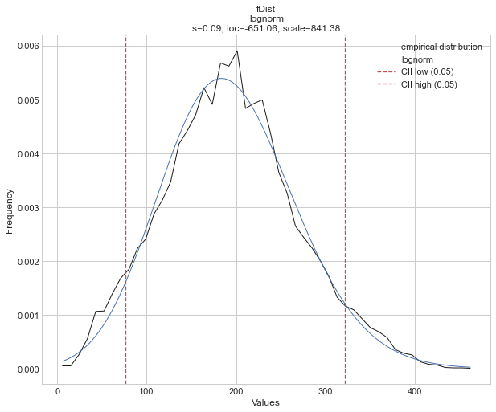

```python
aempty=[]
for i in range(10):
    # Initialize
    dist = distfit()
    # Search for best theoretical fit on your emperical data
    aempty.append(dist.fit_transform(train_X.iloc[:,i].values))#save the RSS results
    # plot
    dist.plot(train_X.columns[i])
```

Now, it is known which is the best distribution for each parameter. The Residual Sum of Squares (RSS) was used to compare.

To have a better idea, the same test of which-distribution-is-the-best-fit is made using Maximum Likelihood Estimation (MLE). Calculating the *negative loglikelihood function* for all the parameter data with the principal distributions that Disfit try before:

```python
dist =[norm, expon, pareto, dweibull, t, genextreme, gamma, lognorm, beta, uniform,logistic,lognorm]#distribution names
mles = []#to save the MLE of each parameter for each distribution
besto=[]
for i in range(10):#for each parameter
  mle_i=[train_X.columns[i],]
  mini=[float('inf'),'none']
  for distribution in dist:#for each distribution
        #obtaining parameters of the distribution from data using MLE estimation
      pars = distribution.fit(train_X.iloc[:,i].values)
        # negative loglikelihood function for the data and the distribution w the parameter's values obtained in the previous line
      mle = distribution.nnlf(pars,train_X.iloc[:,i].values)
      mle_i.append(mle)#saving
      if mle<mini[0]:#looking for the minimum  negative loglikelihood function for each parameter data
        mini=[mle,distribution.name,pars]
  mles.append(mle_i)#saving the MLE for all distributions
  besto.append([train_X.columns[i]]+mini)#save the best

distnames= [distribution.name for distribution in dist]
print(tabulate(mles, headers=["parameter"]+distnames,numalign="right",floatfmt="1.3e",tablefmt="github"))
```

```
| parameter   |       norm |      expon |     pareto |   dweibull |          t |   genextreme |      gamma |    lognorm |       beta |    uniform |   logistic |    lognorm |
|-------------|------------|------------|------------|------------|------------|--------------|------------|------------|------------|------------|------------|------------|
| fLength     |  7.391e+04 |  6.983e+04 |  7.919e+04 |  7.188e+04 |  7.161e+04 |    6.766e+04 |  6.862e+04 |  8.594e+04 |  6.862e+04 |  8.272e+04 |  7.256e+04 |  8.594e+04 |
| fWidth      |  6.197e+04 |  5.851e+04 |  6.743e+04 |  5.702e+04 |  5.607e+04 |    5.460e+04 |  5.621e+04 |  5.516e+04 |  5.622e+04 |  7.912e+04 |  5.876e+04 |  5.516e+04 |
| fSize       |  9.544e+03 |  1.239e+04 |  1.422e+04 |  9.494e+03 |  9.441e+03 |    8.429e+03 |  8.318e+03 |  8.387e+03 |  8.302e+03 |  1.736e+04 |  9.463e+03 |  8.387e+03 |
| fConc       | -3.946e+03 |  2.152e+00 |  2.775e+01 | -3.766e+03 | -3.946e+03 |   -4.479e+03 | -4.565e+03 | -4.484e+03 | -4.748e+03 | -1.825e+03 | -3.634e+03 | -4.484e+03 |
| fConc1      | -1.110e+04 | -7.670e+03 | -7.669e+03 | -1.100e+04 | -1.110e+04 |   -1.195e+04 | -1.206e+04 | -1.199e+04 | -1.211e+04 | -5.609e+03 | -1.095e+04 | -1.199e+04 |
| fAsym       |  7.857e+04 |  1.013e+05 |  1.021e+05 |  7.570e+04 |  7.547e+04 |    1.426e+05 |  7.918e+04 |  1.271e+05 |  7.847e+04 |  9.889e+04 |  7.672e+04 |  1.271e+05 |
| fM3Long     |  7.653e+04 |  9.750e+04 |  9.767e+04 |  7.458e+04 |  7.470e+04 |    1.268e+05 |  7.834e+04 |  7.656e+04 |  7.606e+04 |  9.052e+04 |  7.527e+04 |  7.656e+04 |
| fM3Trans    |  6.366e+04 |  8.705e+04 |  8.721e+04 |  6.195e+04 |  6.164e+04 |    6.560e+04 |  6.368e+04 |  1.141e+05 |  6.365e+04 |  8.332e+04 |  6.208e+04 |  1.141e+05 |
| fAlpha      |  6.680e+04 |  6.165e+04 |  6.169e+04 |  6.624e+04 |  6.680e+04 |    6.346e+04 |  6.156e+04 |  7.113e+04 |  6.050e+04 |  6.419e+04 |  6.708e+04 |  7.113e+04 |
| fDist       |  8.178e+04 |  8.929e+04 |  1.108e+05 |  8.196e+04 |  8.178e+04 |    8.169e+04 |  8.170e+04 |  8.170e+04 |  8.167e+04 |  8.762e+04 |  8.193e+04 |  8.170e+04 |
```

The distribution with the lowest negative loglikelihood function is the best option for fitting.

| parameter | norm | expon | pareto | dweibull | t | genextreme | gamma | lognorm | beta | uniform | logistic | lognorm |
| --- | --- | --- | --- | --- | --- | --- | --- | --- | --- | --- | --- | --- |
| fLength | 7.391e+04 | 6.983e+04 | 7.919e+04 | 7.188e+04 | 7.161e+04 | 6.766e+04 | 6.862e+04 | 8.594e+04 | 6.862e+04 | 8.272e+04 | 7.256e+04 | 8.594e+04 |
| fWidth | 6.197e+04 | 5.851e+04 | 6.743e+04 | 5.702e+04 | 5.607e+04 | 5.460e+04 | 5.621e+04 | 5.516e+04 | 5.622e+04 | 7.912e+04 | 5.876e+04 | 5.516e+04 |
| fSize | 9.544e+03 | 1.239e+04 | 1.422e+04 | 9.494e+03 | 9.441e+03 | 8.429e+03 | 8.318e+03 | 8.387e+03 | 8.302e+03 | 1.736e+04 | 9.463e+03 | 8.387e+03 |
| fConc | -3.946e+03 | 2.152e+00 | 2.775e+01 | -3.766e+03 | -3.946e+03 | -4.479e+03 | -4.565e+03 | -4.484e+03 | -4.748e+03 | -1.825e+03 | -3.634e+03 | -4.484e+03 |
| fConc1 | -1.110e+04 | -7.670e+03 | -7.669e+03 | -1.100e+04 | -1.110e+04 | -1.195e+04 | -1.206e+04 | -1.199e+04 | -1.211e+04 | -5.609e+03 | -1.095e+04 | -1.199e+04 |
| fAsym | 7.857e+04 | 1.013e+05 | 1.021e+05 | 7.570e+04 | 7.547e+04 | 1.426e+05 | 7.918e+04 | 1.271e+05 | 7.847e+04 | 9.889e+04 | 7.672e+04 | 1.271e+05 |
| fM3Long | 7.653e+04 | 9.750e+04 | 9.767e+04 | 7.458e+04 | 7.470e+04 | 1.268e+05 | 7.834e+04 | 7.656e+04 | 7.606e+04 | 9.052e+04 | 7.527e+04 | 7.656e+04 |
| fM3Trans | 6.366e+04 | 8.705e+04 | 8.721e+04 | 6.195e+04 | 6.164e+04 | 6.560e+04 | 6.368e+04 | 1.141e+05 | 6.365e+04 | 8.332e+04 | 6.208e+04 | 1.141e+05 |
| fAlpha | 6.680e+04 | 6.165e+04 | 6.169e+04 | 6.624e+04 | 6.680e+04 | 6.346e+04 | 6.156e+04 | 7.113e+04 | 6.050e+04 | 6.419e+04 | 6.708e+04 | 7.113e+04 |
| fDist | 8.178e+04 | 8.929e+04 | 1.108e+05 | 8.196e+04 | 8.178e+04 | 8.169e+04 | 8.170e+04 | 8.170e+04 | 8.167e+04 | 8.762e+04 | 8.193e+04 | 8.170e+04 |

The best distribution for each parameter are (using MLE):

```python
print(tabulate(besto, headers=["Parameter","Min MLE","Best Distribution","pars"],floatfmt="1.3e",tablefmt="github"))
```

```
| Parameter   |    Min MLE | Best Distribution   | pars                                                                                |
|-------------|------------|---------------------|-------------------------------------------------------------------------------------|
| fLength     |  6.766e+04 | genextreme          | (-0.5168311011076752, 30.620170091516144, 17.712035391223132)                       |
| fWidth      |  5.460e+04 | genextreme          | (-0.2302990459331291, 14.619278332812193, 8.279171747642685)                        |
| fSize       |  8.302e+03 | beta                | (2.9865075466901647, 23.466690106826164, 1.9421685492730938, 7.807898188679667)     |
| fConc       | -4.748e+03 | beta                | (2.3747563441321544, 4.319102239567787, 0.011010372014689334, 1.0462523165345419)   |
| fConc1      | -1.211e+04 | beta                | (2.9205386446315, 11.717734743239793, -0.0023693459483200225, 1.090849660322091)    |
| fAsym       |  7.547e+04 | t                   | (1.8911380046029715, 5.06126445621727, 27.05805512093712)                           |
| fM3Long     |  7.458e+04 | dweibull            | (0.919733391237972, 16.190099999999994, 32.9720695688185)                           |
| fM3Trans    |  6.164e+04 | t                   | (3.6797649833440547, 0.09323594876200089, 13.67041677212795)                        |
| fAlpha      |  6.050e+04 | beta                | (0.6183227106691553, 1.3324627013144175, -4.213909411700232e-28, 91.01981546505654) |
| fDist       |  8.167e+04 | beta                | (5.938498285136098, 9.77054573870754, -44.89030744651807, 630.8748075748614)        |
```

| Parameter | Min MLE | Best Distribution | pars |
| --- | --- | --- | --- |
| fLength | 6.766e+04 | genextreme | (-0.5168311011076752, 30.620170091516144, 17.712035391223132) |
| fWidth | 5.460e+04 | genextreme | (-0.2302990459331291, 14.619278332812193, 8.279171747642685) |
| fSize | 8.302e+03 | beta | (2.9865075466901647, 23.466690106826164, 1.9421685492730938, 7.807898188679667) |
| fConc | -4.748e+03 | beta | (2.3747563441321544, 4.319102239567787, 0.011010372014689334, 1.0462523165345419) |
| fConc1 | -1.211e+04 | beta | (2.9205386446315, 11.717734743239793, -0.0023693459483200225, 1.090849660322091) |
| fAsym | 7.547e+04 | t | (1.8911380046029715, 5.06126445621727, 27.05805512093712) |
| fM3Long | 7.458e+04 | dweibull | (0.919733391237972, 16.190099999999994, 32.9720695688185) |
| fM3Trans | 6.164e+04 | t | (3.6797649833440547, 0.09323594876200089, 13.67041677212795) |
| fAlpha | 6.050e+04 | beta | (0.6183227106691553, 1.3324627013144175, -4.213909411700232e-28, 91.01981546505654) |
| fDist | 8.167e+04 | beta | (5.938498285136098, 9.77054573870754, -44.89030744651807, 630.8748075748614) |

I produce other types of plots with the results above by including results with the MLE and the first results with the *disfit* package. Also, the KS test was made, but the results were not satisfctory.

```python
def plotdist(namee,xval,par,typel,data) :
    #function to plot all distributions
    a=par[0]#a and b are shape parameters of the distribution
    b=par[1]
    c=par[2]#c can be a shape parameter but most of the time is the scale parameter
    if ( namee== "genextreme" ):
        y1 = genextreme.pdf(xval, a,b,c) #the density plot which is essentially a smooth version of the histogram
        label= typel+": Genextreme pdf"
        ksdata=list(kstest(rvs=data, cdf='genextreme',args=par))#KS test result and p value

    elif (namee == "gamma" ):
        xval = np.linspace( max(0.25,min(xval)),max(xval), 200)# I have to add this because when x-> 0, the distribution->inf too fast
        y1= gamma.pdf(xval,a,b,c)#the density plot which is essentially a smooth version of the histogram
        label= typel+": Gamma pdf"
        ksdata=list(kstest(rvs=data, cdf='gamma',args=par))#KS test result and p value

    elif ( namee == "t" ):
        y1= t.pdf(xval,a,b,c)#the density plot which is essentially a smooth version of the histogram
        label= typel+": t pdf"
        ksdata=list(kstest(rvs =data, cdf= 't',args=par))#KS test result and p value

    elif ( namee == "dweibull" ):
        y1= dweibull.pdf(xval,a,b,c)#the density plot which is essentially a smooth version of the histogram
        label= typel+": Dweibull pdf"
        ksdata=list(kstest(rvs =data, cdf='dweibull',args=par))#KS test result and p value

    elif (namee == "beta" ):
        xval = np.linspace( max(0.25,min(xval)),max(xval), 200)#the same reason of the gamma case
        d= par[3]# scale factor
        y1= beta.pdf(xval,a,b,c,d)#the density plot which is essentially a smooth version of the histogram
        label= typel+": Beta pdf"
        ksdata=list(kstest(rvs =data, cdf='beta',args=par))#KS test result and p value

    elif (namee == "lognorm" ):
        y1= lognorm.pdf(xval,a,b,c)#the density plot which is essentially a smooth version of the histogram
        label= typel+": Lognorm pdf"
        ksdata=list(kstest(rvs =data, cdf='lognorm',args=par))#KS test result and p value

    return (y1,label,ksdata)#returns the points for the distribution, label, ks value
```

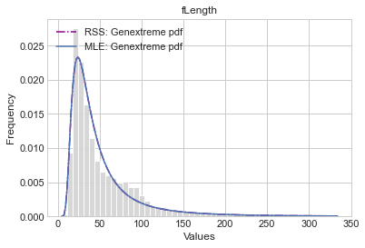

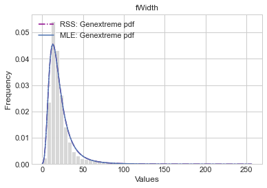

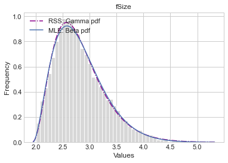

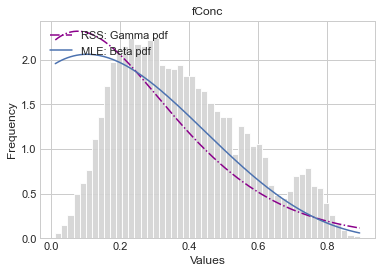

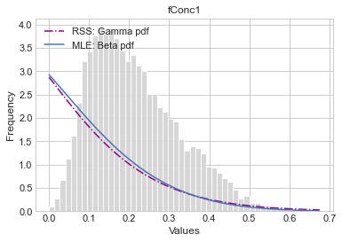

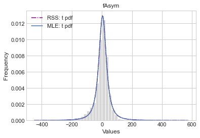

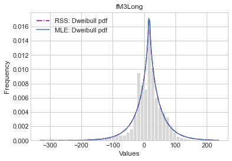

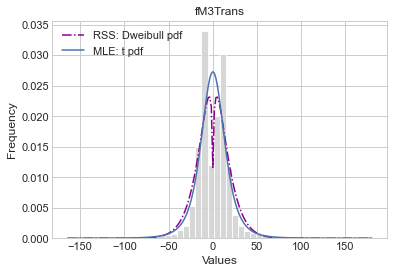

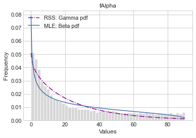

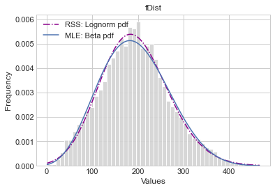

```python
figsize=(30,20)
ksdata1=[]
ksdata2=[]
for i in range(10):
    data=train_X.iloc[:,i].values#each column data
    xval = np.linspace(min(data), max(data), 200)#x points to plot

    #Disfit package
    namee=((aempty[i])['model'])['name'] #best distribution given by disfit package
    par=((aempty[i])['model'])['params'] #parameters for the best distribution statated in the previous line by disfit
    (y_1,label1,ks1)=plotdist(namee,xval,par,"RSS",data)
    ksdata1.append([train_X.columns[i]]+[namee]+ks1)#KS and p value of RSS-disfit result

    #MLE with scipy
    temp=besto[i]#best distribution chosen by minimun negative loglikelihood function
    namee=temp[2]#name
    par=temp[3]#parameters
    (y_2,label2,ks2)=plotdist(namee,xval,par,"MLE",data)
    ksdata2.append([train_X.columns[i]]+[namee]+ks2)#KS and p value of MLE result

    plt.hist(data, bins=aempty[i]['bins'], density=True,color='lightgrey',alpha = 0.9,)#histogram plot

    plt.plot(xval, y_1,linestyle='-.',label=label1,color='darkmagenta')#smooth distribution of the histogram plot for disfit results
    plt.plot(xval, y_2,label=label2,color='b')#smooth distribution of the histogram plot for MLE results
    plt.legend(loc="upper left")
    plt.title(train_X.columns[i])
    plt.xlabel('Values')
    plt.ylabel('Frequency')
    plt.show()
    print('\n')
```

Results of the goodness of the fit ( parameters obtained with Residual Sum of Squares (RSS) - *disfit* package) using the KS-test :

```python
print(tabulate(ksdata1, headers=["parameter","Best distribution fit","KS test statistic","p-value"],numalign="right",tablefmt="github"))#tablefmt="latex"
```

```
| parameter   | Best distribution fit   |   KS test statistic |     p-value |
|-------------|-------------------------|---------------------|-------------|
| fLength     | genextreme              |           0.0505276 | 4.32225e-32 |
| fWidth      | genextreme              |           0.0475182 | 1.97834e-28 |
| fSize       | gamma                   |          0.00933521 |    0.165311 |
| fConc       | gamma                   |           0.0262115 | 6.01853e-09 |
| fConc1      | gamma                   |           0.0190699 | 6.15626e-05 |
| fAsym       | t                       |           0.0477719 | 9.91746e-29 |
| fM3Long     | dweibull                |           0.0701475 | 1.76044e-61 |
| fM3Trans    | dweibull                |           0.0590488 | 1.11829e-43 |
| fAlpha      | gamma                   |           0.0841271 | 2.80465e-88 |
| fDist       | lognorm                 |           0.0114856 |   0.0460398 |
```

| parameter | Best distribution fit | KS test statistic | p-value |
| --- | --- | --- | --- |
| fLength | genextreme | 0.0505276 | 4.32225e-32 |
| fWidth | genextreme | 0.0475182 | 1.97834e-28 |
| fSize | gamma | 0.00933521 | 0.165311 |
| fConc | gamma | 0.0262115 | 6.01853e-09 |
| fConc1 | gamma | 0.0190699 | 6.15626e-05 |
| fAsym | t | 0.0477719 | 9.91746e-29 |
| fM3Long | dweibull | 0.0701475 | 1.76044e-61 |
| fM3Trans | dweibull | 0.0590488 | 1.11829e-43 |
| fAlpha | gamma | 0.0841271 | 2.80465e-88 |
| fDist | lognorm | 0.0114856 | 0.0460398 |

Results of the goodnessof the fit (obtained with Negative Loglikelihood Function -> (MLE) - *scipy* package) using the KS-test :

```python
print(tabulate(ksdata2, headers=["parameter","Best distribution fit","KS test statistic","p-value"],numalign="right",tablefmt="github"))#tablefmt="latex"
```

```
| parameter   | Best distribution fit   |   KS test statistic |     p-value |
|-------------|-------------------------|---------------------|-------------|
| fLength     | genextreme              |           0.0505276 | 4.32225e-32 |
| fWidth      | genextreme              |           0.0475182 | 1.97834e-28 |
| fSize       | beta                    |           0.0109658 |   0.0642539 |
| fConc       | beta                    |           0.0289843 | 7.61679e-11 |
| fConc1      | beta                    |           0.0198265 | 2.65685e-05 |
| fAsym       | t                       |           0.0477719 | 9.91746e-29 |
| fM3Long     | dweibull                |           0.0701475 | 1.76044e-61 |
| fM3Trans    | t                       |           0.0808537 | 1.44717e-81 |
| fAlpha      | beta                    |           0.0683299 | 2.35181e-58 |
| fDist       | beta                    |            0.016181 |  0.00112744 |
```

| parameter | Best distribution fit | KS test statistic | p-value |
| --- | --- | --- | --- |
| fLength | genextreme | 0.0505276 | 4.32225e-32 |
| fWidth | genextreme | 0.0475182 | 1.97834e-28 |
| fSize | beta | 0.0109658 | 0.0642539 |
| fConc | beta | 0.0289843 | 7.61679e-11 |
| fConc1 | beta | 0.0198265 | 2.65685e-05 |
| fAsym | t | 0.0477719 | 9.91746e-29 |
| fM3Long | dweibull | 0.0701475 | 1.76044e-61 |
| fM3Trans | t | 0.0808537 | 1.44717e-81 |
| fAlpha | beta | 0.0683299 | 2.35181e-58 |
| fDist | beta | 0.016181 | 0.00112744 |

Using the Kolomogorov-Smirov this results are obtained (but the parameters for location, scale, and shape are estimated from the data, and https://www.statisticshowto.com/kolmogorov-smirnov-test/ says that this invalidates the test.)

# Building models

Our aim is to find the best model to predict if the Cherenkov photons collected, are caused by primary gammas (signal) from the images of hadronic showers or initiated by cosmic rays in the upper atmosphere (background).

After reading and testing, Normalizing the data do not affect the classifiers that do not need normalized data. So normalizing data for all classifiers do not affect negatively

```python
#Scaling
sc = StandardScaler()
train_X = sc.fit_transform(train_X)
val_X = sc.transform(val_X)
sct=StandardScaler()
X=sct.fit_transform(X)
```

```python
def print_score(clf, X_train, y_train, X_test, y_test, train=True):

    #To debug, dont actually used
    if train:
        pred = clf.predict(X_train)
        print("Train Result:\n===========================================")
        print(f"accuracy score: {accuracy_score(y_train, pred):.4f}\n")
        print(f"Classification Report: \n \tPrecision: {precision_score(y_train, pred)}\n\tRecall Score: {recall_score(y_train, pred)}\n\tF1 score: {f1_score(y_train, pred)}\n")
        print(f"Confusion Matrix: \n {confusion_matrix(y_train, clf.predict(X_train))}\n")

    #this is the used part:
    elif train==False:
        pred = clf.predict(X_test)#we predict new results
        print("Test Result:\n===========================================")
        print(f"accuracy score: {accuracy_score(y_test, pred)}\n")#accuracy of the results comparing with the real values
        print(f"Classification Report: \n \tPrecision: {precision_score(y_test, pred)}\n\tRecall Score: {recall_score(y_test, pred)}\n\tF1 score: {f1_score(y_test, pred)}\n")
        print(f"Confusion Matrix: \n")# {confusion_matrix(y_test, pred)}\n")
        con_matrix=confusion_matrix(y_test, pred)
        t_cm=[["True F"]+list(con_matrix[0]),["True T"]+list(con_matrix[1])]
        print(tabulate(t_cm,headers=["      ","Predicted F","Predicted T"],tablefmt="psql"))
        t_cm_r=[np.array(con_matrix)[0]/np.sum(np.array(con_matrix)[0]),np.array(con_matrix)[1]/np.sum(np.array(con_matrix)[1])]
        t_cm_r=[["True F"]+list(t_cm_r[0]),["True T"]+list(t_cm_r[1])]
        print("\nRelative Confusion Matrix: \n")# {confusion_matrix(y_test, pred)}\n")
        print(tabulate(t_cm_r,headers=["      ","Predicted F","Predicted T"],tablefmt="psql",floatfmt="1.3"))
```

```python
def ROC_plot(model,title):
    #Almost every model available makes a continuous approximation before
    #mapping it to a hard prediction. Usually, in the scikit-learn models, these
    #continuous outputs can be accessed through the predict_proba method
    probs = model.predict_proba(val_X)
    #the second column are the probability of signal
    preds = probs[:,1]
    #the roc_curve function return the values for the plot of ROC. false positive rate,true positive rate
    fprd, tprd, thresholdd = roc_curve(val_y, preds)
    roc_aucd = auc(fprd, tprd)#area under the curve

    plt.plot(fprd, tprd, 'b', label = 'AUC = %0.2f' % roc_aucd)
    plt.plot([0, 1], [0, 1],'r--')
    plt.title('Receiver Operating Characteristic '+title,fontsize=12)
    plt.ylabel('True Positive Rate',fontsize=12)
    plt.xlabel('False Positive Rate',fontsize=12)
    plt.legend(loc = 'lower right', prop={'size': 12})
    plt.show()
    return (roc_aucd,fprd, tprd)
```

```python
#@title
#for using this first it's needed to train a logistic classificator
#first fit pls
#The trees and forest classifiers do not make a continuous approximation before mapping it to a hard prediction.
#so they cannot produce a ROC curve with the same method as the previous function
# we use the metod given in http://mlwiki.org/index.php/ROC_Analysis
#for this, we need a ranker, we can use the Logistic Regression outputs probabilities
def ROC_trees(val_X,model,logmodel,class_name):
    probs = model.predict_proba(val_X)
    #the step up must sum 1 and is given by the signals
    #the step to the right must sum 1 and is given by the background
    step_up=1/sum(probs[:,1])
    step_rigth=1/sum(probs[:,0])

    #obtaining the continous values of the Logistic Regression to rank the values of the data
    valor_bin=model.predict_proba(val_X)#2 columns of data (probability of background, probabilty of signal)
    #in the case of the tree (or a forest) the probabilities can only be 1 or 0
    #we asign steps values for each value
    valor_bin[:,0]=valor_bin[:,0]*step_rigth
    valor_bin[:,1]=valor_bin[:,1]*step_up
    stept=valor_bin[:,0]# this line is used latter to calculate the area under the curve
    valor_bin=valor_bin.tolist()#to list

    # use the probability of signal predicted by the logmodel to make the score order for each event
    score=list(logmodel.predict_proba(val_X)[:,1])

    Z = [x for _,x in sorted(zip(score,valor_bin),reverse=True)]#order each event in function of its score from the highest score to the lowest
    Z=np.array(Z)

    pandaZx=pd.Series(Z[:,0])#to panda format
    pandaZY=pd.Series(Z[:,1])#to panda format
    cumu_x=(pandaZx.cumsum()).tolist()#cumulative sum of right steps
    cumu_y=(pandaZY.cumsum()).tolist()#cumulative sum of up steps

    finalll=np.zeros((len(cumu_x)+1,2))#creating a zero array to add all the steps and an initial step 0,0
    finalll[1:,0]=cumu_x#adding the cumulative sum
    finalll[1:,1]=cumu_y#adding the cumulative sum

    #area under the curve
    ordersteps = [x for _,x in sorted(zip(score,stept),reverse=True)]#we order the steps to the right
    AUC=sum(ordersteps*np.array(cumu_y))

    plt.plot(finalll[:,0],finalll[:,1], 'b', label = 'AUC = %0.2f' % AUC)
    plt.plot([0, 1], [0, 1],'r--')
    plt.title('Receiver Operating Characteristic '+class_name,fontsize=12)
    plt.ylabel('True Positive Rate',fontsize=12)
    plt.xlabel('False Positive Rate',fontsize=12)
    plt.legend(loc = 'lower right', prop={'size': 12})
    plt.show()
    #to save the results for latter
    return (AUC,finalll[:,0], finalll[:,1])
```

## Logistic Regression 📉📈📉

### No boosted parameters

```python
#the classifier
logmodel = LogisticRegression()
#training
logmodel.fit(train_X, train_y)

# Make validation predictions and calculate precition
print_score(logmodel, train_X, train_y, val_X, val_y, train=False)
```

```
Test Result:
===========================================
accuracy score: 0.7911671924290221

Classification Report:
 	Precision: 0.8007497116493656
	Recall Score: 0.9019162065605716
	F1 score: 0.8483274782343058

Confusion Matrix:

+----------+---------------+---------------+
|          |   Predicted F |   Predicted T |
|----------+---------------+---------------|
| True F   |           985 |           691 |
| True T   |           302 |          2777 |
+----------+---------------+---------------+

Relative Confusion Matrix:

+----------+---------------+---------------+
|          |   Predicted F |   Predicted T |
|----------+---------------+---------------|
| True F   |        0.588  |         0.412 |
| True T   |        0.0981 |         0.902 |
+----------+---------------+---------------+
```

```python
#saving the result for later
ac0 =accuracy_score(val_y, logmodel.predict(val_X))
```

#### ROC curve

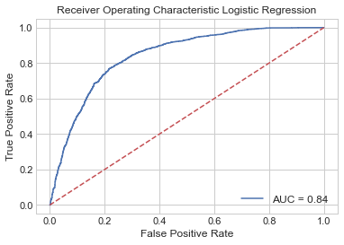

```python
(r0,rx0,ry0)=ROC_plot(logmodel,"Logistic Regression")
```

#### Cross validation

```python
score0  =cross_val_score(logmodel, X, y, cv=5, scoring='accuracy')# in 5 groups
print('Mean Accuracy Score LR w no parameters: %2f' %(score0.mean()))
```

```
Mean Accuracy Score LR w no parameters: 0.790799
```

### Best hyperparameters given by GridSearchCV package

Grid search is the process of performing an exhaustive search over specified values in order to determine the optimal hyperparameter values for a given model.

```python
#classifier
LR = LogisticRegression()
```

```python
params_LR={'max_iter':range(100,1000,100)}
params_LR['solver'] = ['newton-cg', 'lbfgs', 'liblinear']
params_LR['penalty'] = ['none', 'l1', 'l2', 'elasticnet']
params_LR['C'] = [1e-5, 1e-2,1e2]
```

The package realize cross-validation in 5 groups with "accuracy" as the parameter of scoring

```python
LR_GS = GridSearchCV(
        estimator=LR,
        param_grid=params_LR,
        cv=5, scoring='accuracy', verbose=0, n_jobs=-1)
```

when fit is applied to the GridSearchCV the best params to give the best accuracy for the test data is searched

```python
LR_result = LR_GS.fit(train_X,train_y)
LR_params = LR_result.best_params_#the resultant best parameters
LR_params
```

```
{'C': 100.0, 'max_iter': 200, 'penalty': 'l1', 'solver': 'liblinear'}
```

This hiperparameter is used to build a Best Logistic Regression Classifier

```python
best_LR=LogisticRegression(max_iter=LR_params["max_iter"],
                                solver=LR_params["solver"],
                                penalty=LR_params["penalty"],
                                C=LR_params["C"],
                                );
best_LR.fit(train_X,train_y);
print_score(best_LR, train_X, train_y, val_X, val_y, train=False)
```

```
Test Result:
===========================================
accuracy score: 0.7911671924290221

Classification Report:
 	Precision: 0.8007497116493656
	Recall Score: 0.9019162065605716
	F1 score: 0.8483274782343058

Confusion Matrix:

+----------+---------------+---------------+
|          |   Predicted F |   Predicted T |
|----------+---------------+---------------|
| True F   |           985 |           691 |
| True T   |           302 |          2777 |
+----------+---------------+---------------+

Relative Confusion Matrix:

+----------+---------------+---------------+
|          |   Predicted F |   Predicted T |
|----------+---------------+---------------|
| True F   |        0.588  |         0.412 |
| True T   |        0.0981 |         0.902 |
+----------+---------------+---------------+
```

```python
#saving the result for later
ac1 =accuracy_score(val_y, best_LR.predict(val_X))
```

#### ROC curve

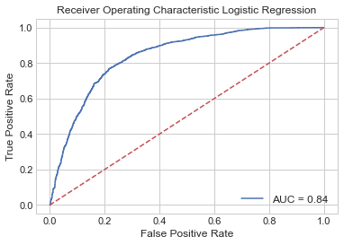

```python
(r1,rx1,ry1)=ROC_plot(best_LR,"Logistic Regression")
```

#### Cross validation

Let's prove how these values of the hyperparameters work on all the data (not only in the test data). Also, the Cross-validation is performed to validate the slice of data results.

```python
score1  =cross_val_score(best_LR, X, y, cv=5, scoring='accuracy')
print('Mean Accuracy Score LR w best parameters: %2f' %(score1.mean()))
```

```
Mean Accuracy Score LR w best parameters: 0.790641
```

### Best parameter by RandomSearchCV package

GridSearchCV is computationally-time expensive, especially when searching over a large hyperparameter space and dealing with multiple hyperparameters. A solution to this is to use RandomizedSearchCV, in which not all hyperparameter values are tried out. Instead, a fixed number of hyperparameter settings is sampled from specified probability distributions.

```python
lr = LogisticRegression()
```

Proving values for max_iter:Maximum number of iterations taken for the solvers to converge (default=100). Values were tested from 100 to 1000 in steps of 5

This is a dictionary where names are arguments to the model and values are distributions from which to draw samples. We will optimize the solver, the penalty, and the C hyperparameters of the model with discrete distributions for the solver and penalty type and a log-uniform distribution from 1e-5 to 100 for the C value.

Log-uniform is useful for searching values as we often explore values at different orders of magnitude.

```python
params_lr={'max_iter':range(100,1000,5)}
params_lr['solver'] = ['newton-cg', 'lbfgs', 'liblinear']
params_lr['penalty'] = ['none', 'l1', 'l2', 'elasticnet']
params_lr['C'] = loguniform(1e-5, 100)
```

```python
lr_RS = RandomizedSearchCV(estimator=lr, param_distributions=params_lr,
                           n_iter = 20, scoring='accuracy', cv =5, verbose=2, random_state=0, n_jobs=-1)
```

when fit is applied to the GridSearchCV the best params to give the best accuracy for the test data is searched

```python
lr_result = lr_RS.fit(train_X,train_y)
lr_params = lr_result.best_params_
lr_params
```

```
Fitting 5 folds for each of 20 candidates, totalling 100 fits
```

```
[Parallel(n_jobs=-1)]: Using backend LokyBackend with 4 concurrent workers.
[Parallel(n_jobs=-1)]: Done  86 tasks      | elapsed:    1.7s
[Parallel(n_jobs=-1)]: Done 100 out of 100 | elapsed:    2.0s finished
```

```
{'C': 0.06945356257424773,
 'max_iter': 685,
 'penalty': 'none',
 'solver': 'lbfgs'}
```

The hyperparameters are used to built a better Logistic Regression Classifier

```python
best_lr=LogisticRegression(max_iter=lr_params["max_iter"],
                                solver=lr_params["solver"],
                                penalty=lr_params["penalty"],
                                C=lr_params["C"],
                                );
best_lr.fit(train_X,train_y);
print_score(best_lr, train_X, train_y, val_X, val_y, train=False)
```

```
Test Result:
===========================================
accuracy score: 0.7911671924290221

Classification Report:
 	Precision: 0.8007497116493656
	Recall Score: 0.9019162065605716
	F1 score: 0.8483274782343058

Confusion Matrix:

+----------+---------------+---------------+
|          |   Predicted F |   Predicted T |
|----------+---------------+---------------|
| True F   |           985 |           691 |
| True T   |           302 |          2777 |
+----------+---------------+---------------+

Relative Confusion Matrix:

+----------+---------------+---------------+
|          |   Predicted F |   Predicted T |
|----------+---------------+---------------|
| True F   |        0.588  |         0.412 |
| True T   |        0.0981 |         0.902 |
+----------+---------------+---------------+
```

```python
#saving the result for later
ac1b =accuracy_score(val_y, best_lr.predict(val_X))
```

#### ROC curve

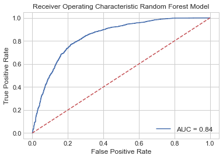

```python
(r1b,rx1b,ry1b)=ROC_plot(best_lr,"Random Forest Model")
```

#### Cross validation

Let's prove how these values of the hyperparameters work on all the data (not only in the test data). Also, the Cross-validation is performed to validate the slice of data results.

```python
score1b  =cross_val_score(best_lr, X, y, cv=5, scoring='accuracy')
print('Mean Accuracy Score RFC w best parameters: %2f' %(score1b.mean()))
```

```
Mean Accuracy Score RFC w best parameters: 0.790641
```

## Decision Tree Model 🌳

### No boosted parameters

```python
# Specify Model
decision_tree_model = DecisionTreeClassifier(criterion='entropy',random_state = 0)

# Fit Model
decision_tree_model.fit(train_X, train_y)

# Make validation predictions and calculate precition
print_score(decision_tree_model, train_X, train_y, val_X, val_y, train=False)
print(f'leaves:{decision_tree_model.get_n_leaves()}')
```

```
Test Result:
===========================================
accuracy score: 0.8143007360672976

Classification Report:
 	Precision: 0.8621372031662269
	Recall Score: 0.8489769405651185
	F1 score: 0.8555064637538864

Confusion Matrix:

+----------+---------------+---------------+
|          |   Predicted F |   Predicted T |
|----------+---------------+---------------|
| True F   |          1258 |           418 |
| True T   |           465 |          2614 |
+----------+---------------+---------------+

Relative Confusion Matrix:

+----------+---------------+---------------+
|          |   Predicted F |   Predicted T |
|----------+---------------+---------------|
| True F   |         0.751 |         0.249 |
| True T   |         0.151 |         0.849 |
+----------+---------------+---------------+
leaves:1347
```

```python
#saving the result for later
#pudo ir antes en la función de display de resultados pero me iba a costar tiempo reevaluar
ac2 =accuracy_score(val_y, decision_tree_model.predict(val_X))
```

#### ROC curve

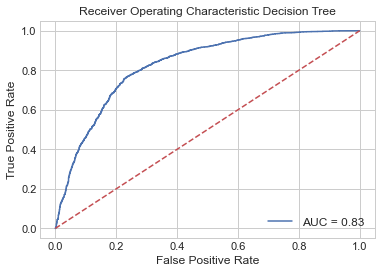

```python
# Make validation predictions and calculate precition
(r2,rx2,ry2)=ROC_trees(val_X,decision_tree_model,best_lr,"Decision Tree")
```

#### Cross validation

```python
score2  =cross_val_score(decision_tree_model, X, y, cv=5, scoring='accuracy')# in 5 groups
print('Mean Accuracy Score DTC w no parameters: %2f' %(score2.mean()))
```

```
Mean Accuracy Score DTC w no parameters: 0.818139
```

### Best parameters given by GridSearchCV package

Grid search is the process of performing hyper parameter tuning in order to determine the optimal values for a given model. Also the function preforms cross-validation

```python
DTC = DecisionTreeClassifier(criterion='entropy',random_state = 0)
```

Proving values for

*max_depth*: The maximum depth of the tree. If None, then nodes are expanded until all leaves are pure or until all leaves contain less than min_samples_split samples. Values were tested from 10 to 50 in steps of 5.

*max_leaf_nodes*: max_leaf_nodes in best-first fashion. Best nodes are defined as relative reduction in impurity. If None then unlimited number of leaf nodes. Values were tested from 10 to 200 in steps of 10.

```python
params_DTC={'max_depth':range(10,50,5), 'max_leaf_nodes':range(10,200,10)}
```

The package realize cross-validation in 5 groups with "accuracy" as the parameter of scoring

```python
DTC_GS = GridSearchCV(
        estimator=DTC,
        param_grid=params_DTC,
        cv=5, scoring='accuracy', verbose=0, n_jobs=-1)
```

```python
DTC_result = DTC_GS.fit(train_X,train_y)
DTC_params = DTC_result.best_params_
DTC_params
```

```
{'max_depth': 15, 'max_leaf_nodes': 100}
```

```python
best_DTC=DecisionTreeClassifier(criterion='entropy',random_state = 0,max_depth=DTC_params["max_depth"],max_leaf_nodes=DTC_params["max_leaf_nodes"]);
best_DTC.fit(train_X,train_y);
print_score(best_DTC, train_X, train_y, val_X, val_y, train=False)
```

```
Test Result:
===========================================
accuracy score: 0.8515247108307045

Classification Report:
 	Precision: 0.8538622129436325
	Recall Score: 0.9298473530367002
	F1 score: 0.89023631840796

Confusion Matrix:

+----------+---------------+---------------+
|          |   Predicted F |   Predicted T |
|----------+---------------+---------------|
| True F   |          1186 |           490 |
| True T   |           216 |          2863 |
+----------+---------------+---------------+

Relative Confusion Matrix:

+----------+---------------+---------------+
|          |   Predicted F |   Predicted T |
|----------+---------------+---------------|
| True F   |        0.708  |         0.292 |
| True T   |        0.0702 |         0.93  |
+----------+---------------+---------------+
```

```python
#saving the result for later
#pudo ir antes en la función de display de resultados pero me iba a costar tiempo reevaluar
ac3 =accuracy_score(val_y, best_DTC.predict(val_X))
```

#### ROC curve

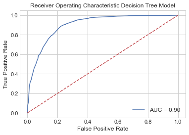

```python
(r3,rx3,ry3)=ROC_plot(best_DTC,"Decision Tree Model")
```

#### Cross validation

```python
score3  =cross_val_score(best_DTC, X, y, cv=5, scoring='accuracy')
print('Mean Accuracy Score DTC w best parameters: %2f' %(score3.mean()))
```

```
Mean Accuracy Score DTC w best parameters: 0.850053
```

### Best parameter by RandomSearchCV package

GridSearchCV is computationally-time expensive, especially when searching over a large hyperparameter space and dealing with multiple hyperparameters. A solution to this is to use RandomizedSearchCV, in which not all hyperparameter values are tried out. Instead, a fixed number of hyperparameter settings is sampled from specified probability distributions.

```python
dtc = DecisionTreeClassifier(criterion='entropy',random_state = 0)
```

```python
params_dtc={'max_depth':range(10,50), 'max_leaf_nodes':range(10,200)}
```

Proving values for

*max_depth*: The maximum depth of the tree. If None, then nodes are expanded until all leaves are pure or until all leaves contain less than min_samples_split samples. Values were tested from 10 to 50.

*max_leaf_nodes*: max_leaf_nodes in best-first fashion. Best nodes are defined as relative reduction in impurity. If None then unlimited number of leaf nodes. Values were tested from 10 to 200.

```python
dtc_RS = RandomizedSearchCV(estimator=dtc, param_distributions=params_dtc, n_iter = 20, scoring='accuracy', cv =5, verbose=2, random_state=0, n_jobs=-1)
```

```python
dtc_result = dtc_RS.fit(train_X,train_y)
dtc_params = dtc_result.best_params_
dtc_params
```

```
Fitting 5 folds for each of 20 candidates, totalling 100 fits
```

```
[Parallel(n_jobs=-1)]: Using backend LokyBackend with 4 concurrent workers.
[Parallel(n_jobs=-1)]: Done  33 tasks      | elapsed:    5.5s
[Parallel(n_jobs=-1)]: Done 100 out of 100 | elapsed:   15.7s finished
```

```
{'max_leaf_nodes': 104, 'max_depth': 45}
```

```python
best_dtc=DecisionTreeClassifier(criterion='entropy',random_state = 0,
                       max_depth=dtc_params["max_depth"],
                       max_leaf_nodes=dtc_params["max_leaf_nodes"]);

best_dtc.fit(train_X,train_y);
print_score(best_dtc, train_X, train_y, val_X, val_y, train=False)
```

```
Test Result:
===========================================
accuracy score: 0.8511041009463722

Classification Report:
 	Precision: 0.8533532041728763
	Recall Score: 0.9298473530367002
	F1 score: 0.8899595896798259

Confusion Matrix:

+----------+---------------+---------------+
|          |   Predicted F |   Predicted T |
|----------+---------------+---------------|
| True F   |          1184 |           492 |
| True T   |           216 |          2863 |
+----------+---------------+---------------+

Relative Confusion Matrix:

+----------+---------------+---------------+
|          |   Predicted F |   Predicted T |
|----------+---------------+---------------|
| True F   |        0.706  |         0.294 |
| True T   |        0.0702 |         0.93  |
+----------+---------------+---------------+
```

```python
#saving the result for later
#pudo ir antes en la función de display de resultados pero me iba a costar tiempo reevaluar
ac3b =accuracy_score(val_y, best_dtc.predict(val_X))
```

#### ROC curve

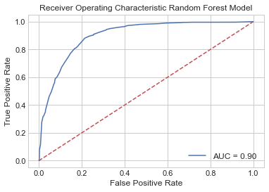

```python
(r3b,rx3b,ry3b)=ROC_plot(best_dtc,"Random Forest Model")
```

#### Cross validation

```python
score3b  =cross_val_score(best_dtc, X, y, cv=5, scoring='accuracy')
print('Mean Accuracy Score RFC w best parameters: %2f' %(score3b.mean()))
```

```
Mean Accuracy Score RFC w best parameters: 0.849790
```

## Random Forest Model 🌲🌳🌲

### No boosted parameters

```python
# Define the model. Set random_state to 1
rf_model  = RandomForestClassifier(criterion = 'entropy', random_state = 0)

# fit your model
rf_model.fit(train_X, train_y)

# Calculate the mean absolute error of your Random Forest model on the validation data
print_score(rf_model, train_X, train_y, val_X, val_y, train=False)
print(f'parameters:{rf_model.get_params()}')
```

```
Test Result:
===========================================
accuracy score: 0.8858044164037855

Classification Report:
 	Precision: 0.8816977724262492
	Recall Score: 0.951282884053264
	F1 score: 0.9151695047648805

Confusion Matrix:

+----------+---------------+---------------+
|          |   Predicted F |   Predicted T |
|----------+---------------+---------------|
| True F   |          1283 |           393 |
| True T   |           150 |          2929 |
+----------+---------------+---------------+

Relative Confusion Matrix:

+----------+---------------+---------------+
|          |   Predicted F |   Predicted T |
|----------+---------------+---------------|
| True F   |        0.766  |         0.234 |
| True T   |        0.0487 |         0.951 |
+----------+---------------+---------------+
parameters:{'bootstrap': True, 'ccp_alpha': 0.0, 'class_weight': None, 'criterion': 'entropy', 'max_depth': None, 'max_features': 'auto', 'max_leaf_nodes': None, 'max_samples': None, 'min_impurity_decrease': 0.0, 'min_impurity_split': None, 'min_samples_leaf': 1, 'min_samples_split': 2, 'min_weight_…
```

```python
#saving the result for later
#pudo ir antes en la función de display de resultados pero me iba a costar tiempo reevaluar
ac4 =accuracy_score(val_y, rf_model.predict(val_X))
```

#### ROC curve

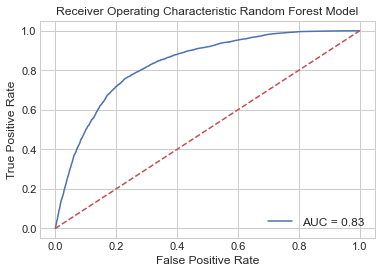

```python
(r4,rx4,ry4)=ROC_trees(val_X,rf_model,best_lr,"Random Forest Model")
```

#### Cross validation

```python
score4  =cross_val_score(rf_model, X, y, cv=5, scoring='accuracy')# in 5 groups
print('Mean Accuracy Score RFC w no parameters: %2f' %(score4.mean()))
```

```
Mean Accuracy Score RFC w no parameters: 0.880967
```

### Best parameters given by GridSearchCV package

Grid search is the process of performing hyper parameter tuning in order to determine the optimal values for a given model. Also the function preforms cross-validation

```python
RFC = RandomForestClassifier(criterion='entropy',random_state = 0)
```

```python
params_RFC= {  'bootstrap': [True], 'max_depth': [5,10,50,100,None],
             'max_features': ['auto', 'log2'], 'n_estimators':[50,100,150,200,250,500,1000]}
```

Proving values for

*n_estimators*: (default=100) The number of trees in the forest. Values were tested from 50 to 1000

*bootstrapbool*: (default=True) Whether bootstrap samples are used when building trees. If False, the whole dataset is used to build each tree.

*max_features*{“auto”, “sqrt”, “log2”}:( default=”auto”) The number of features to consider when looking for the best split

*max_depth*: The maximum depth of the tree. If None, then nodes are expanded until all leaves are pure or until all leaves contain less than min_samples_split samples. Values were tested from 5 to 100

The package realize cross-validation in 5 groups with "accuracy" as the parameter of scoring

```python
RFC_GS = GridSearchCV(
        estimator=RFC,
        param_grid=params_RFC,
        cv=5, scoring='accuracy', verbose=0, n_jobs=-1)
```

```python
RFC_result = RFC_GS.fit(train_X,train_y)
RFC_params = RFC_result.best_params_
RFC_params
```

```
{'bootstrap': True,
 'max_depth': 50,
 'max_features': 'auto',
 'n_estimators': 250}
```

```python
best_RFC=RandomForestClassifier(criterion='entropy',random_state = 0,
                                bootstrap=RFC_params["bootstrap"],
                                max_depth=RFC_params["max_depth"],
                                max_features=RFC_params["max_features"],
                                n_estimators=RFC_params["n_estimators"],
                                );
best_RFC.fit(train_X,train_y);
print_score(best_RFC, train_X, train_y, val_X, val_y, train=False)
```

```
Test Result:
===========================================
accuracy score: 0.8858044164037855

Classification Report:
 	Precision: 0.882157926461724
	Recall Score: 0.9506333225073076
	F1 score: 0.9151164608410194

Confusion Matrix:

+----------+---------------+---------------+
|          |   Predicted F |   Predicted T |
|----------+---------------+---------------|
| True F   |          1285 |           391 |
| True T   |           152 |          2927 |
+----------+---------------+---------------+

Relative Confusion Matrix:

+----------+---------------+---------------+
|          |   Predicted F |   Predicted T |
|----------+---------------+---------------|
| True F   |        0.767  |         0.233 |
| True T   |        0.0494 |         0.951 |
+----------+---------------+---------------+
```

```python
#saving the result for later
#pudo ir antes en la función de display de resultados pero me iba a costar tiempo reevaluar
ac5 =accuracy_score(val_y, best_RFC.predict(val_X))
```

#### ROC curve

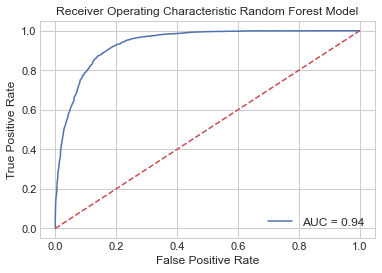

```python
(r5,rx5,ry5)=ROC_plot(best_RFC,"Random Forest Model")
```

#### Cross validation

```python
score5  =cross_val_score(best_RFC, X, y, cv=5, scoring='accuracy')
print('Mean Accuracy Score RFC w best parameters: %2f' %(score5.mean()))
```

```
Mean Accuracy Score RFC w best parameters: 0.881073
```

### Best parameter by RandomSearchCV package

GridSearchCV is computationally-time expensive, especially when searching over a large hyperparameter space and dealing with multiple hyperparameters. A solution to this is to use RandomizedSearchCV, in which not all hyperparameter values are tried out. Instead, a fixed number of hyperparameter settings is sampled from specified probability distributions.

```python
rfc = RandomForestClassifier(criterion='entropy',random_state = 0)
```

```python
params_rfc= { 'bootstrap': [True], 'max_depth': list(range(5,100))+[ None],
             'max_features': ['auto', 'log2'], 'n_estimators':range(50,1000)}
```

Proving values for

*n_estimators*: (default=100) The number of trees in the forest. Values were tested from 50 to 1000

*bootstrapbool*: (default=True) Whether bootstrap samples are used when building trees. If False, the whole dataset is used to build each tree.

*max_features*{“auto”, “sqrt”, “log2”}:( default=”auto”) The number of features to consider when looking for the best split

```python
rfc_RS = RandomizedSearchCV(estimator=rfc, param_distributions=params_rfc, n_iter = 20, scoring='accuracy',
                            cv =5, verbose=2, random_state=0, n_jobs=-1)
```

```python
rfc_result = rfc_RS.fit(train_X,train_y)
rfc_params = rfc_result.best_params_
rfc_params
```

```
Fitting 5 folds for each of 20 candidates, totalling 100 fits
```

```
[Parallel(n_jobs=-1)]: Using backend LokyBackend with 4 concurrent workers.
[Parallel(n_jobs=-1)]: Done  33 tasks      | elapsed:  9.8min
[Parallel(n_jobs=-1)]: Done 100 out of 100 | elapsed: 26.5min finished
```

```
{'n_estimators': 200,
 'max_features': 'log2',
 'max_depth': 30,
 'bootstrap': True}
```

```python
best_rfc=RandomForestClassifier(criterion='entropy',random_state = 0,
                                bootstrap=rfc_params["bootstrap"],
                                max_depth=rfc_params["max_depth"],
                                max_features=rfc_params["max_features"],
                                n_estimators=rfc_params["n_estimators"],
                                );
best_rfc.fit(train_X,train_y);
print_score(best_rfc, train_X, train_y, val_X, val_y, train=False)
```

```
Test Result:
===========================================
accuracy score: 0.8843322818086226

Classification Report:
 	Precision: 0.8826021180030257
	Recall Score: 0.9473855147775252
	F1 score: 0.9138471177944862

Confusion Matrix:

+----------+---------------+---------------+
|          |   Predicted F |   Predicted T |
|----------+---------------+---------------|
| True F   |          1288 |           388 |
| True T   |           162 |          2917 |
+----------+---------------+---------------+

Relative Confusion Matrix:

+----------+---------------+---------------+
|          |   Predicted F |   Predicted T |
|----------+---------------+---------------|
| True F   |        0.768  |         0.232 |
| True T   |        0.0526 |         0.947 |
+----------+---------------+---------------+
```

```python
#saving the result for later
#pudo ir antes en la función de display de resultados pero me iba a costar tiempo reevaluar
ac5b =accuracy_score(val_y, best_rfc.predict(val_X))
```

#### ROC curve

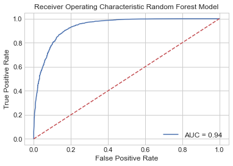

```python
(r5b,rx5b,ry5b)=ROC_plot(best_rfc,"Random Forest Model")
```

#### Cross validation

```python
score5b  =cross_val_score(best_rfc, X, y, cv=5, scoring='accuracy')
print('Mean Accuracy Score RFC w best parameters: %2f' %(score5b.mean()))
```

```
Mean Accuracy Score RFC w best parameters: 0.880652
```